# Exercise 12

Chenwei Xiao

2020/12/02

The purpose of this exercise is to create a CNN model for a multiclass classification problem.

So far, a binary classification problem was considered. However, in practice, there are several cases where more than 2 classes have to be considered. For example, the [mnist](https://en.wikipedia.org/wiki/MNIST_database) dataset consists of handwritten digit images and in total contains 10 different classes (number 0 to number 9).

The goal of this exercise is to create a model that takes the handwritten image as input and predicts the number which is written in this image.

Regarding the modelling part of multiclass classification problem the only thing that changes, compared to a binary classification problem, is the number of nodes and the activation function on the output layer. Also, a different loss function has to be considered (‘categorical_crossentropy’). In other words, the number of nodes of the output layer should equal the number of discrete classes (10 in our case). Furthermore, the activation function of the output layer is the ‘softmax’ activation which converts each output node to a probability of the corresponding class. Therefore, for a prediction, we choose the class where its node gives the maximum probability.

Furthermore, a skeleton code is provided which does the preprocessing and creates a baseline model.

Your task is to create a CNN architecture that outperforms the baseline model. The data are class balanced so accuracy can be used in this case. You should use dropout and/or regularization to avoid overfitting. Also, comment on the number of trainable parameters for each model.

### Import libraries

```r
library(reticulate)
use_condaenv()
library(keras)
library(tensorflow)
library(tidyverse)
library(rsample)
```

IMPORTANT NOTE: READ CAREFULLY!

Do not skip this part or you’ll run into issues later on! In a moment, after you’ve read the following instructions carefully, you should: - run the code chunk immediately below this text (`keras_model_sequential()`). - look down in the *Console* it asks if you want to install some packages: (“Would you like to install Miniconda? [Y/n]:”). - write *n* and press enter. You should see the following code in the console: `Would you like to install Miniconda? [Y/n]: n`. Now, you can normally continue with the exercise.

If you were too eager and already pressed *Y* (yes) and enter, don’t panic! Just close your environment, re-open it and make sure that next time you go with *n* (no).

```r
keras_model_sequential()
```

### Load mnist dataset

```r
mnist = dataset_mnist()

# take train and test set
train = mnist$train
test = mnist$test
```

### Plot an image

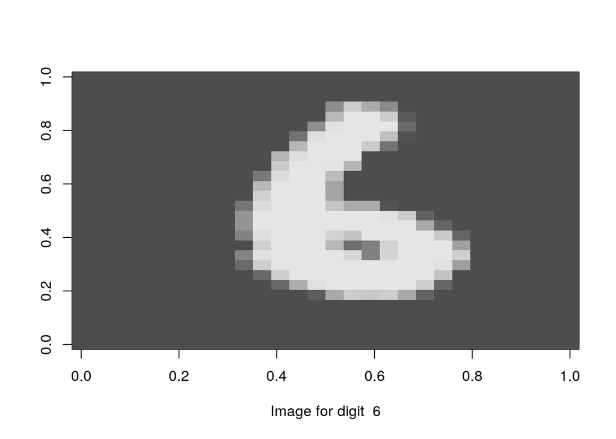

```r
index_image = 37 ## change this index to see different image.
input_matrix = train$x[index_image,,]
output_matrix <- apply(input_matrix, 2, rev)
output_matrix <- t(output_matrix)
image(output_matrix, col=gray.colors(256), xlab=paste('Image for digit ', train$y[index_image]), ylab="")
```

### Specify image size and number of classes

```r
img_size = dim(train$x)[2:3]
img_channels = 1
n_classes = length(unique(train$y))
cat('Image size: ',c(img_size,img_channels),"\n")
```

```
## Image size:  28 28 1
```

```r
cat('Total classes: ',n_classes)
```

```
## Total classes:  10
```

### Create a validation set using stratified split and rescale input to [0,1]

```r
#make stratified split
split = initial_split(data.frame('y'=train$y),prop = 0.8,strata = 'y')

#train set
x_train = train$x[split$in_id,,]
##rescale to [0,1]
x_train = x_train/255
y_train = train$y[split$in_id]

#validation set
x_val = train$x[-split$in_id,,]
##rescale to [0,1]
x_val = x_val/255
y_val = train$y[-split$in_id]

#test set
x_test = test$x
##rescale to [0,1]
x_test = x_test/255
y_test = test$y
```

### Encode classes to one-hot vectors

```r
y_train = to_categorical(y_train, n_classes)
y_val =  to_categorical(y_val,n_classes)
y_test = to_categorical(y_test, n_classes)

head(y_train)
```

```
##      [,1] [,2] [,3] [,4] [,5] [,6] [,7] [,8] [,9] [,10]
## [1,]    0    0    0    0    0    1    0    0    0     0
## [2,]    1    0    0    0    0    0    0    0    0     0
## [3,]    0    0    0    0    1    0    0    0    0     0
## [4,]    0    1    0    0    0    0    0    0    0     0
## [5,]    0    0    0    0    0    0    0    0    0     1
## [6,]    0    0    1    0    0    0    0    0    0     0
```

### Create and train the baseline model

A simple approach would be to create a vector (flatten the 2d input matrix) from the input image and then to apply a feed-forward neural network (i.e. dense layers). You are already provided with a trained model (because it takes a long time to train it from scratch), so you do not have to run the fit function. You just have to load the model.

You don’t have to run the following chunk but have a look at this model nevertheless.

```r
# eval = F means that the knit will not run this chunk
ffnn_model = keras_model_sequential()

ffnn_model %>% layer_flatten(input_shape = img_size) %>%
          layer_dense(units = 1024,activation = 'relu')%>%
          layer_dense(units = 512,activation = 'relu')%>%
          layer_dense(units = 256,activation = 'relu') %>%
          layer_dense(units = 128,activation = 'relu') %>%
          layer_dense(units = 10,activation = 'softmax')

ffnn_model %>% compile(
  loss = 'categorical_crossentropy',
  optimizer = optimizer_adam(lr = 0.001),
  metrics = c('accuracy')
)

dir.create(file.path('saved_models'))
save_ffnn = file.path('saved_models','baseline.h5')

callbacks_ffnn = list(callback_early_stopping(monitor='val_loss',patience = 5,mode = 'min'),
                      callback_model_checkpoint(save_ffnn,monitor='val_loss',save_best_only = T,mode = 'min'))

#history_ffnn = fit(ffnn_model,x_train, y_train, epochs = 20, batch_size = 128,
#                  validation_data = list(x_val,y_val),callbacks = callbacks_ffnn)
```

### Load the saved Baseline model and evaluate the performance on validation and test set

```r
save_ffnn = file.path('saved_models','baseline.h5')
model_ffnn = load_model_hdf5(save_ffnn)

#evalute accuracy
val_acc = evaluate(model_ffnn,x_val,y_val)$acc
test_acc = evaluate(model_ffnn,x_test,y_test)$acc

cat('Validation Accuracy: ',val_acc,'\n')
```

```
## Validation Accuracy:  0.9883304
```

```r
cat('Test Accuracy: ',test_acc,'\n')
```

```
## Test Accuracy:  0.9798
```

### Create a CNN architecture

```r
build_model <- function(L2_rate = 0, drop_rate = 0){
  #Name the model
  model.name = paste('convnet_L2_',L2_rate,'_dropout_',drop_rate,sep="")

  #sequential model
  model = keras_model_sequential(name = model.name)

  model = model %>%

    layer_conv_2d(filter = 32 , kernel_size = c(3,3),activation = 'relu',input_shape = c(img_size,img_channels)) %>%

    #Add a max pooling layer with 2x2 windows. This will halve the dimension of data.
    layer_max_pooling_2d(pool_size = c(2,2)) %>%

    layer_dropout(rate = drop_rate)%>%

    layer_conv_2d(filter = 64 , kernel_size = c(3,3),activation = 'relu',kernel_regularizer =  regularizer_l2(l =  L2_rate)) %>%

    #Add a max pooling layer with 2x2 windows. This will halve the dimension of data.
    layer_max_pooling_2d(pool_size = c(2,2)) %>%

    #Squash the output of the final max pooling layer into a 1D vector
    layer_flatten()%>%

    #add a dropout layer here
    layer_dropout(rate = drop_rate)%>%

    #Use this 1D vector as input to a single dense layer with 256 neurons
    #add L2 regularization
    layer_dense(units = 256,activation = 'relu',kernel_regularizer =  regularizer_l2(l =  L2_rate)) %>%

    #Finally, add a 10 neuron dense layer with a softmax activation function
    layer_dense(units = n_classes,activation = 'softmax')

    #Print out a model summary
    summary(model)

    return(model)

}
```

#### Train the model

Hint: reshape your inputs so that they match the desired dimension of the input_shape in `layer_conv_2d`. Use callbacks for early stopping and model checkpoint (look at the baseline model).

```r
compile_and_train = function(cnn_model, learning_rate, max_epochs){

  cnn_model %>% compile(
    loss = 'categorical_crossentropy',
    optimizer = optimizer_adam(lr = learning_rate),
    metrics = c('accuracy')
  )
  dir.create(file.path('saved_models'))
  save_cnn = file.path('saved_models','cnn_models.h5')

  callbacks_cnn = list(
    callback_reduce_lr_on_plateau(monitor = "val_loss",patience = 3 ,factor = 0.1),
    callback_early_stopping(monitor='val_loss',patience = 5,mode = 'min'),
    callback_model_checkpoint(save_cnn,monitor='val_loss',save_best_only = T,mode = 'min'))

  history_cnn = fit(
    cnn_model,x_train_reshape, y_train, epochs = max_epochs, batch_size = 128,
    validation_data = list(x_val_reshape,y_val),callbacks = callbacks_cnn)

  return (history_cnn)

}

# reshape input x
x_train_reshape <- array_reshape(x_train,dim = c(-1,img_size,img_channels))
x_val_reshape <- array_reshape(x_val,dim = c(-1,img_size,img_channels))
dim(x_train_reshape)
```

```
## [1] 48003    28    28     1
```

```r
# compile and train the model
model_dropout = build_model(0, 0.5)
```

```
## Model: "convnet_L2_0_dropout_0.5"
## ________________________________________________________________________________
## Layer (type)                        Output Shape                    Param #
## ================================================================================
## conv2d (Conv2D)                     (None, 26, 26, 32)              320
## ________________________________________________________________________________
## max_pooling2d (MaxPooling2D)        (None, 13, 13, 32)              0
## ________________________________________________________________________________
## dropout (Dropout)                   (None, 13, 13, 32)              0
## ________________________________________________________________________________
## conv2d_1 (Conv2D)                   (None, 11, 11, 64)              18496
## ________________________________________________________________________________
## max_pooling2d_1 (MaxPooling2D)      (None, 5, 5, 64)                0
## ________________________________________________________________________________
## flatten (Flatten)                   (None, 1600)                    0
## ________________________________________________________________________________
## dropout_1 (Dropout)                 (None, 1600)                    0
## ________________________________________________________________________________
## dense (Dense)                       (None, 256)                     409856
## ________________________________________________________________________________
## dense_1 (Dense)                     (None, 10)                      2570
## ================================================================================
## Total params: 431,242
## Trainable params: 431,242
## Non-trainable params: 0
## ________________________________________________________________________________
```

```r
history_dropout = compile_and_train(model_dropout, 1e-3, 100)
```

#### Load the saved model, evaluate performance on validation and test set

```r
save_cnn = file.path('saved_models','cnn_models.h5')
model_dropout = load_model_hdf5(save_cnn)

# evalute accuracy
# reshape the test input x
x_test_reshape <- array_reshape(x_test,dim = c(-1,img_size,img_channels))

val_acc = evaluate(model_dropout,x_val_reshape,y_val)$acc
test_acc = evaluate(model_dropout,x_test_reshape,y_test)$acc

cat('Validation Accuracy: ',val_acc,'\n')
```

```
## Validation Accuracy:  0.9988331
```

```r
cat('Test Accuracy: ',test_acc,'\n')
```

```
## Test Accuracy:  0.9934
```

```r
summary(model_ffnn)
```

```
## Model: "sequential_2"
## ________________________________________________________________________________
## Layer (type)                        Output Shape                    Param #
## ================================================================================
## flatten_2 (Flatten)                 (None, 784)                     0
## ________________________________________________________________________________
## dense_10 (Dense)                    (None, 1024)                    803840
## ________________________________________________________________________________
## dense_11 (Dense)                    (None, 512)                     524800
## ________________________________________________________________________________
## dense_12 (Dense)                    (None, 256)                     131328
## ________________________________________________________________________________
## dense_13 (Dense)                    (None, 128)                     32896
## ________________________________________________________________________________
## dense_14 (Dense)                    (None, 10)                      1290
## ================================================================================
## Total params: 1,494,154
## Trainable params: 1,494,154
## Non-trainable params: 0
## ________________________________________________________________________________
```

```r
summary(model_dropout)
```

[output not shown]